# Getting started with cellpacman

## Overview

`cellpacman` (PAinted Cell and coMpound ANalysis) models how cell morphology changes as the concentration of a compound increases, using well-level Cell Painting features. For every *known* compound, i.e. one tested over a concentration series, the package summarizes the morphological response as a one-dimensional curve in a low-dimensional embedding: a **concentration trajectory**. *Unknown* compounds, tested at a single concentration without annotation, are then interpreted by projecting them onto these trajectories, which yields both the most similar known compound and an interpolated effective concentration.

The workflow is a chain of six functions. Each returns an S3 object that is the input of the next, so intermediate results can be inspected, plotted, or re-used:

| Step | Function | Output class | What it does |
| --- | --- | --- | --- |
| 1 | `loadCellPainting()` | `cellpainting_data` | Reads and validates the feature and metadata tables. |
| 2 | `normalize()` | `cellpainting_normalized` | z-scores every feature within plate. |
| 3 | `dimReduce()` | `cellpainting_dimred` | Embeds the normalized profiles in two dimensions with UMAP. |
| 4 | `compoundCluster()` | `cellpainting_clusters` | Runs DBSCAN per known compound and jointly on the unknown wells. |
| 5 | `curveEstimate()` | `cellpainting_curves` | Fits a principal curve through each known compound’s concentration-ordered centroids. |
| 6 | `curveProject()` | list | Projects unknown-cluster centroids onto every trajectory and interpolates a concentration. |

Two feature-selection functions (`selectFeatureCurve()`, `selectFeatureCluster()`) and two pairwise comparison functions (`compareCompoundFeatures()`, `compareClusterFeatures()`) then explain *which* features drive a trajectory or separate two groups of wells. This vignette runs the complete workflow on the example screen bundled with the package.

```r
library(cellpacman)
library(dplyr)
library(tidyr)
library(ggplot2)
```

## Input data

`cellpacman` expects two tables that share a `WellId` key:

- a **feature table** whose first column is `WellId` and whose remaining columns are numeric morphological features (one row per well), and
- a **metadata table** with at least `WellId`, `Plate`, `Compound`, and `Concentration`. Any additional columns are carried along unchanged.

`Compound` encodes the known/unknown distinction: a non-missing value marks a well of a known compound, and `NA` marks an unknown well. `Concentration` must be numeric and is only used for known compounds. Both tables may be supplied as data frames or as paths to `csv`, `tsv`, `txt`, or `xlsx` files.

### The example screen

The package ships a fully synthetic screen of 2,000 wells across eight plates, with 600 numeric features (`exampleDataPath()`). The filenames are `example_features_mock.tsv` and `example_metadata_mock.tsv`. Each plate has 250 occupied positions on a 384-position grid: three fictitious references (`RefA`, `RefB`, `RefC`) at eight concentrations in duplicate, 16 synthetic DMSO controls, and 186 unknown wells. In total there are 384 reference wells, 128 control wells and 1,488 unknown wells.

All measurements and experimental identifiers are synthetic. Concentrations use arbitrary tutorial units; the plotting helpers display a unit-neutral concentration label. No real compound effects or experimental results are represented. This example demonstrates execution and interpretation of the software outputs, not biological validation or concentration-recovery accuracy.

```r
dat <- loadCellPainting(
  file.feature  = exampleDataPath("features"),
  file.metadata = exampleDataPath("metadata")
)

dim(dat$feature_data)
```

```
#> [1] 2000  601
```

```r
dat$metadata |>
  mutate(Compound = ifelse(is.na(Compound), "(unknown)", Compound)) |>
  group_by(Compound) |>
  summarise(
    wells = n(),
    plates = n_distinct(Plate),
    concentrations = n_distinct(Concentration, na.rm = TRUE),
    .groups = "drop"
  ) |>
  knitr::kable()
```

| Compound | wells | plates | concentrations |
| --- | --- | --- | --- |
| (unknown) | 1488 | 8 | 1 |
| DMSO | 128 | 8 | 1 |
| RefA | 128 | 8 | 8 |
| RefB | 128 | 8 | 8 |
| RefC | 128 | 8 | 8 |

### Preparing your own input

Instrument software usually exports one wide table that mixes features and annotation. The bundled mock tables already have the two-table input structure; they were generated synthetically rather than split from an instrument export. For your own data, `readCellPainting()` preserves column names containing spaces. Feature names from Harmony typically contain `"NonBorder Cells"`, so this split can be used for a suitable export (`PlateResults.tsv` stands for your own file):

```r
raw <- readCellPainting("PlateResults.tsv")   # your own Harmony export

feature_tbl  <- raw |> select(WellId, contains("NonBorder Cells"))
metadata_tbl <- raw |> select(!contains("NonBorder Cells"))

dat <- loadCellPainting(feature_tbl, metadata_tbl)
```

`loadCellPainting()` rejects duplicated `WellId`s, non-numeric feature columns, missing required metadata columns, and feature wells without metadata, so malformed input fails at this step rather than deep inside the analysis.

## Preprocessing

### Within-plate standardization

Raw morphological features are measured on incommensurable scales and are subject to plate-level technical variation. `normalize()` therefore standardizes every feature within each plate: for feature $j$ on plate $k$, each well value $x_{ijk}$ is replaced by $z_{ijk} = (x_{ijk} - \bar{x}_{jk}) / s_{jk}$, where $\bar{x}_{jk}$ and $s_{jk}$ are the mean and standard deviation over all wells of that plate. Features with zero variance on a plate are set to 0. The `by` argument accepts any set of metadata columns, so standardization can also be stratified by batch or cell line.

```r
dat_norm <- normalize(dat, method = "z.score", by = "Plate")
```

Standardizing against all wells on a plate (rather than against the vehicle controls alone) assumes that most wells show a modest phenotype; this holds for the typical screen in which unknown wells dominate the plate. The normalized object `dat_norm` is reused by every feature-selection step below.

### Two-dimensional embedding

`dimReduce()` embeds the standardized profiles into two dimensions with UMAP (`umap::umap()`, `n_components = 2`, `min_dist = 0.25`). The embedding is deterministic for a given `random_seed`. Subsequent steps operate on these two coordinates, stored as `x` and `y` in `reduced_data` together with the metadata.

```r
dat_dr <- dimReduce(dat_norm, method = "umap", random_seed = 17)
head(dat_dr$reduced_data[, c("WellId", "Plate", "Compound", "Concentration", "x", "y")])
```

```
#> # A tibble: 6 × 6
#>   WellId           Plate      Compound Concentration     x     y
#>   <chr>            <chr>      <chr>            <dbl> <dbl> <dbl>
#> 1 ToyPlate11R06C08 ToyPlate11 <NA>              0.75 -2.69 -2.96
#> 2 ToyPlate11R06C09 ToyPlate11 <NA>              0.75  6.75  5.68
#> 3 ToyPlate11R06C10 ToyPlate11 <NA>              0.75  5.92  6.30
#> 4 ToyPlate11R06C11 ToyPlate11 <NA>              0.75 19.4   1.19
#> 5 ToyPlate11R06C12 ToyPlate11 <NA>              0.75  6.25  5.80
#> 6 ToyPlate11R06C13 ToyPlate11 <NA>              0.75  5.72  5.91
```

`plotDimred()` draws the embedding with unknown wells in gray and known compounds in color:

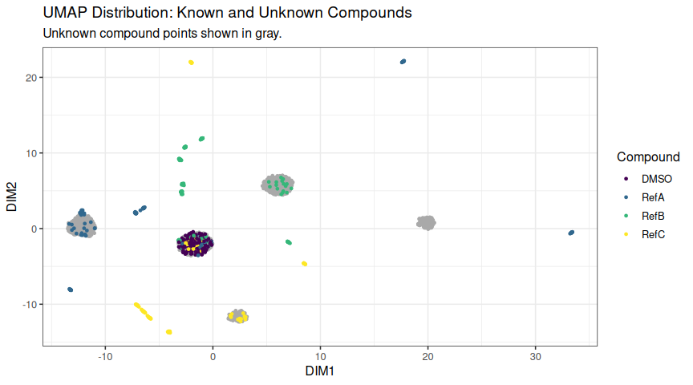

```r
plotDimred(dat_dr)
```

Colouring the same embedding by plate is a useful check that the within-plate standardization has removed plate effects: the eight plates should overlap rather than form separate islands.

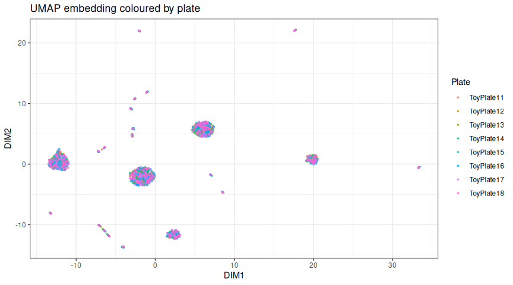

```r
ggplot(dat_dr$reduced_data, aes(x, y, colour = Plate)) +
  geom_point(size = 0.6, alpha = 0.7) +
  labs(x = "DIM1", y = "DIM2", title = "UMAP embedding coloured by plate") +
  theme_bw()
```

## Clustering

Replicate wells of the same compound at the same concentration are expected to occupy a common region of the embedding. `compoundCluster()` recovers these groups with DBSCAN (`eps`, `minPts`), run

- **separately for each known compound**, using only that compound’s wells, and
- **jointly for all unknown wells**.

DBSCAN labels points that do not belong to any dense region as noise (cluster `"0"`). For each cluster the function records its centroid and, for known compounds, the mean concentration of its members; known-compound clusters are sorted by this mean concentration, which is what orders them along the trajectory in the next step.

```r
clusters <- compoundCluster(dat_dr, method = "dbscan", eps = 0.5, minPts = 5)

sapply(clusters$known_clusters, nrow)   # clusters per known compound
```

```
#> RefB RefC RefA DMSO
#>    7    6    6    1
```

```r
clusters$unknown_centroids              # unknown clusters
```

```
#> # A tibble: 5 × 4
#>   cluster mean_x  mean_y point_count
#>   <fct>    <dbl>   <dbl>       <int>
#> 1 1        -1.65  -2.08          368
#> 2 2         6.05   5.80          400
#> 3 3        19.9    0.754         160
#> 4 4         2.35 -11.6           160
#> 5 5       -12.2    0.316         400
```

For the unknown wells, clustering is the primary result: each cluster is a candidate phenotype that will be matched to a known compound.

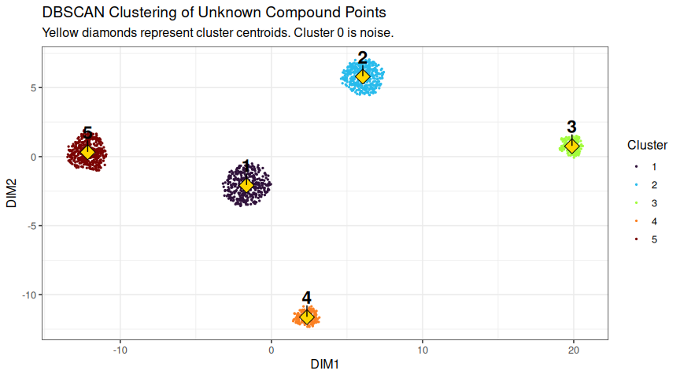

```r
plotUnknownClusters(clusters)
```

For a known compound, the clusters summarize the concentration series. The centroids (diamonds) are labelled with the mean concentration of their wells:

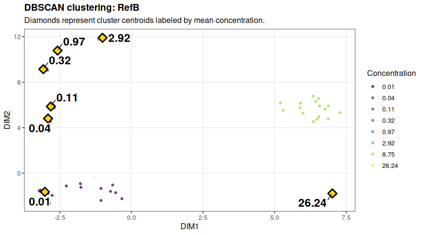

```r
plotKnownClusters(clusters, compound = "RefB")
```

`eps` controls how finely a concentration series is resolved. A compound whose wells form a single connected region at a given `eps` yields only one cluster and therefore no trajectory; decreasing `eps` resolves sub-clusters, at the cost of labelling more wells as noise. With the settings used here, each of the three fictitious references has multiple clusters and yields a trajectory. The synthetic DMSO controls form one cluster and therefore do not yield a trajectory.

## Concentration trajectories

`curveEstimate()` summarizes the graded morphological response of each known compound by a **principal curve** (Hastie and Stuetzle, 1989) fitted to that compound’s non-noise wells (`princurve::principal_curve()`, `smoother = "lowess"` by default). The fit is initialized at the polyline that connects the cluster centroids in order of increasing mean concentration. The fitted curve can bend or reorder their projections, so that initialization does not guarantee monotone concentration along arc length. This occurs for some references in the mock example. The arc length $\lambda$ indexes position along the fitted curve.

Each centroid is mapped to the nearest point of the curve, which gives a set of reference pairs $(\lambda_r, c_r)$ of arc length and mean concentration. These pairs are the calibration that turns a position on the curve into an estimated concentration. A curve requires at least two clusters; compounds with fewer are skipped.

```r
curves <- curveEstimate(dat_dr, method = "princurve", eps = 0.5, minPts = 5, smoother = "lowess")

names(curves$curves)
```

```
#> [1] "RefB" "RefC" "RefA"
```

```r
curves$curves[["RefB"]]$ref_points
```

```
#> # A tibble: 7 × 2
#>   known_arc_length_ref concentration_ref
#>                  <dbl>             <dbl>
#> 1                0.374             0.012
#> 2                6.76              0.036
#> 3                7.81              0.108
#> 4               11.0               0.324
#> 5               12.6               0.972
#> 6               14.4               2.92
#> 7               30.3              26.2
```

The remainder of this vignette focuses on the fictitious reference `RefB`.

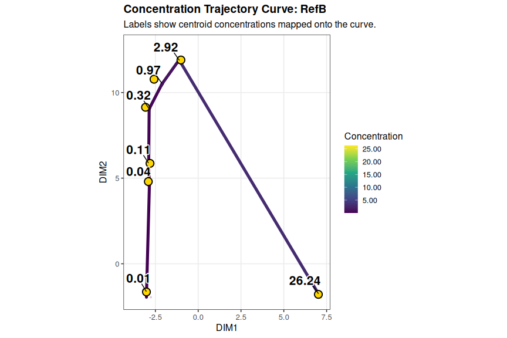

```r
focus_compound <- "RefB"
plotKnownCurves(curves, compound = focus_compound)
```

## Matching unknown compounds to trajectories

`curveProject()` projects the centroid of every unknown cluster onto every fitted trajectory (`princurve::project_to_curve()`). For each pair it reports

- `distance`: the Euclidean distance between the centroid and its projection (how far the unknown phenotype is from the trajectory);
- `arc_length`: the position of the projection along the curve; and
- `estimated_concentration`: the concentration obtained by piecewise-linear interpolation of the reference pairs at that arc length (positions beyond the first or last reference are clamped to the nearest reference).

`best_matches` keeps, for every unknown cluster, the trajectory with the smallest distance.

```r
proj <- curveProject(curves)

proj$best_matches |>
  transmute(
    `Unknown cluster` = unknown_cluster,
    `Best-match compound` = compound,
    `Estimated concentration` = signif(estimated_concentration, 3),
    `Distance to curve` = round(distance, 2)
  ) |>
  arrange(`Unknown cluster`) |>
  knitr::kable()
```

| Unknown cluster | Best-match compound | Estimated concentration | Distance to curve |
| --- | --- | --- | --- |
| 1 | RefB | 0.012 | 1.38 |
| 2 | RefB | 26.100 | 3.03 |
| 3 | RefC | 8.730 | 12.60 |
| 4 | RefC | 2.880 | 0.28 |
| 5 | RefA | 0.945 | 0.92 |

The full `projections` table holds every cluster-by-compound pair, so the margin between the best and second-best match can be examined before a cluster is interpreted. `plotUnknownProjections()` overlays the unknown centroids, their projections, and the estimated concentrations on one compound’s trajectory:

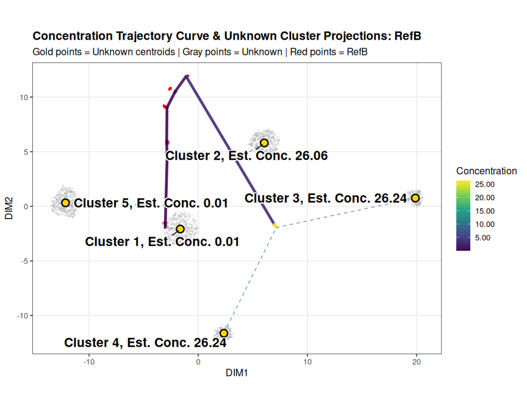

```r
plotUnknownProjections(curves, proj, compound = focus_compound)
```

## Feature selection

All feature-selection functions take the normalized data (`dat_norm`) and use a two-sided Wilcoxon rank-sum test per feature, the difference in medians as the effect size, and a multiplicity correction across features. The tests are rank-based, so they are insensitive to the heavy tails that are common in morphological features.

### Features that change along a trajectory

`selectFeatureCurve()` splits each known compound’s wells at the median arc length into a low- and a high-concentration group and tests every feature between them (Bonferroni-adjusted by default). To show *how* a feature changes rather than only *whether* it changes, the wells are also binned along the arc length (`n_bins`) and the ten most significant features are averaged per bin (`heatmap_data`).

```r
feat_curve <- selectFeatureCurve(curves, data.norm = dat_norm, p.adjust = "bonferroni", cutoff = 0.05)

feat_curve[[focus_compound]]$top_10 |>
  mutate(feature = sub("^NonBorder Cells - (CP_ )?", "", feature)) |>
  select(feature, median_difference, adjusted_p_value, significance) |>
  knitr::kable(digits = 3)
```

| feature | median_difference | adjusted_p_value | significance |
| --- | --- | --- | --- |
| Nucleus Region PhenoVue 512 Nucleic acid stain 488ex 650-760em Haralick Contrast 2 px - Mean per Well | -1.037 | 0 | Negative |
| Nucleus Region PhenoVue 512 Nucleic acid stain 488ex 650-760em Haralick Homogeneity 2 px - Mean per Well | -1.048 | 0 | Negative |
| Cytoplasm Region PhenoVue Fluor 568 561ex 605-630em Radial Relative Deviation - Mean per Well | -1.259 | 0 | Negative |
| Ring Region PhenoVue 512 Nucleic acid stain 488ex 650-760em Symmetry 12 - Mean per Well | 1.089 | 0 | Positive |
| Ring Region PhenoVue Fluor 568 561ex 605-630em Haralick Correlation 2 px - Mean per Well | 1.150 | 0 | Positive |
| Intensity CP_ Ring Region PhenoVue 641 Mito Stain CV [%] - Mean per Well | 0.893 | 0 | Positive |
| Ring Region PhenoVue 641 Mito Stain Symmetry 13 - Mean per Well | 1.360 | 0 | Positive |
| Intensity CP_ Ring Region PhenoVue Fluor 555 561ex 571-596em StdDev - Mean per Well | 0.872 | 0 | Positive |
| Intensity CP_ Ring Region PhenoVue Fluor 568 561ex 605-630em StdDev - Mean per Well | 1.273 | 0 | Positive |
| Cytoplasm Region PhenoVue Fluor 568 561ex 605-630em Threshold Compactness 50% - Mean per Well | 1.007 | 0 | Positive |

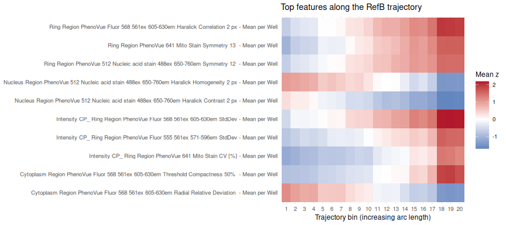

```r
feat_curve[[focus_compound]]$heatmap_data |>
  pivot_longer(-c(bin, mean_concentration), names_to = "feature", values_to = "value") |>
  mutate(feature = sub("^NonBorder Cells - (CP_ )?", "", feature)) |>
  ggplot(aes(factor(bin), feature, fill = value)) +
  geom_tile() +
  scale_fill_gradient2(low = "#2166ac", mid = "white", high = "#b2182b") +
  labs(
    x = "Trajectory bin (increasing arc length)", y = NULL, fill = "Mean z",
    title = paste("Top features along the", focus_compound, "trajectory")
  ) +
  theme_minimal(base_size = 9)
```

### Features that distinguish unknown clusters

`selectFeatureCluster()` compares every pair of unknown clusters and returns one row per comparison and feature. The volcano plots show which features separate the candidate phenotypes:

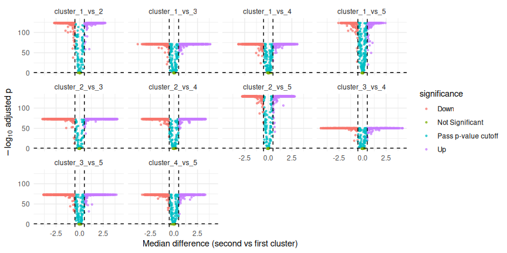

```r
feat_cluster <- selectFeatureCluster(clusters, data.norm = dat_norm)

ggplot(feat_cluster, aes(median_difference, -log10(adjusted_p_value), colour = significance)) +
  geom_point(size = 0.8, alpha = 0.7) +
  geom_hline(yintercept = -log10(0.05), linetype = "dashed") +
  geom_vline(xintercept = c(-0.5, 0.5), linetype = "dashed") +
  facet_wrap(~ comparison) +
  labs(x = "Median difference (second vs first cluster)", y = expression(-log[10]~"adjusted p")) +
  theme_minimal()
```

### Comparing any two groups

`compareCompoundFeatures()` contrasts any two compounds, where `NA` stands for the pooled unknown wells, and `compareClusterFeatures()` contrasts two clusters of one compound. Both use Benjamini–Hochberg adjustment by default. Here all wells of fictitious reference `RefB`, pooled across concentrations, are compared with the synthetic vehicle controls:

```r
compareCompoundFeatures(dat_norm, first = "DMSO", second = "RefB") |>
  head(5) |>
  mutate(feature = sub("^NonBorder Cells - (CP_ )?", "", feature)) |>
  knitr::kable(digits = 3)
```

| feature | median_difference | p_value | adjusted_p_value | significance |
| --- | --- | --- | --- | --- |
| Ring Region PhenoVue Fluor 488ex 500-530em Profile 5/5 - Mean per Well | 0.927 | 0 | 0 | Positive |
| Intensity CP_ Ring Region PhenoVue 641 Mito Stain Contrast - Mean per Well | 0.770 | 0 | 0 | Positive |
| Cytoplasm Region PhenoVue Fluor 555 561ex 571-596em SER Hole 2 px - Mean per Well | -1.448 | 0 | 0 | Negative |
| Ring Region PhenoVue Fluor 555 561ex 571-596em SER Valley 2 px - Mean per Well | 1.077 | 0 | 0 | Positive |
| Ring Region PhenoVue 512 Nucleic acid stain 488ex 650-760em SER Spot 2 px - Mean per Well | 0.974 | 0 | 0 | Positive |

## Interactive analysis

The same workflow is available as a Shiny application, `cellpacman-shiny`, which is distributed alongside the package and calls the functions used in this vignette. It is described in `vignette("shiny-app", package = "cellpacman")`.

## References

Hastie, T. and Stuetzle, W. (1989). Principal curves. *Journal of the American Statistical Association*, 84(406), 502–516.

Ester, M., Kriegel, H.-P., Sander, J. and Xu, X. (1996). A density-based algorithm for discovering clusters in large spatial databases with noise. *Proceedings of KDD-96*, 226–231.

McInnes, L., Healy, J. and Melville, J. (2018). UMAP: Uniform Manifold Approximation and Projection for dimension reduction. *arXiv:1802.03426*.